# Part_I_exploration_template22

## Introduction

> This [dataset](https://www.google.com/url?q=https://www.fordgobike.com/system-data&sa=D&ust=1554484977399000) includes information about individual rides made in a bike-sharing system covering the greater San Francisco Bay area. This document explores the dataset.

## Preliminary Wrangling

```python
# import all packages and set plots to be embedded inline
import numpy as np
import pandas as pd
import matplotlib.pyplot as plt
import seaborn as sb
import time
%matplotlib inline
```

> Load in your dataset and describe its properties through the questions below. Try and motivate your exploration goals through this section.

```python
data = pd.read_csv('fordgobike-tripdata.csv')
data.head()
```

|  | duration_sec | start_time | end_time | start_station_id | start_station_name | start_station_latitude | start_station_longitude | end_station_id | end_station_name | end_station_latitude | end_station_longitude | bike_id | user_type | member_birth_year | member_gender | bike_share_for_all_trip |
| --- | --- | --- | --- | --- | --- | --- | --- | --- | --- | --- | --- | --- | --- | --- | --- | --- |
| 0 | 52185 | 2019-02-28 17:32:10.1450 | 2019-03-01 08:01:55.9750 | 21.0 | Montgomery St BART Station (Market St at 2nd St) | 37.789625 | -122.400811 | 13.0 | Commercial St at Montgomery St | 37.794231 | -122.402923 | 4902 | Customer | 1984.0 | Male | No |
| 1 | 42521 | 2019-02-28 18:53:21.7890 | 2019-03-01 06:42:03.0560 | 23.0 | The Embarcadero at Steuart St | 37.791464 | -122.391034 | 81.0 | Berry St at 4th St | 37.775880 | -122.393170 | 2535 | Customer | NaN | NaN | No |
| 2 | 61854 | 2019-02-28 12:13:13.2180 | 2019-03-01 05:24:08.1460 | 86.0 | Market St at Dolores St | 37.769305 | -122.426826 | 3.0 | Powell St BART Station (Market St at 4th St) | 37.786375 | -122.404904 | 5905 | Customer | 1972.0 | Male | No |
| 3 | 36490 | 2019-02-28 17:54:26.0100 | 2019-03-01 04:02:36.8420 | 375.0 | Grove St at Masonic Ave | 37.774836 | -122.446546 | 70.0 | Central Ave at Fell St | 37.773311 | -122.444293 | 6638 | Subscriber | 1989.0 | Other | No |
| 4 | 1585 | 2019-02-28 23:54:18.5490 | 2019-03-01 00:20:44.0740 | 7.0 | Frank H Ogawa Plaza | 37.804562 | -122.271738 | 222.0 | 10th Ave at E 15th St | 37.792714 | -122.248780 | 4898 | Subscriber | 1974.0 | Male | Yes |

### What is the structure of your dataset?

This dataset includes 183412 trips with 16 features.

[output not shown]

### What is/are the main feature(s) of interest in your dataset?

> I am most interested in figuring out when and where are most trips taken because this dataset includes start time/location and end time/location. I focus on the starting points first.  
> Also, I am interested in what are the characteristics (age, sex, and user_type) of the riders and the duration of the trips in these time points and locations.

### What features in the dataset do you think will help support your investigation into your feature(s) of interest?

I expect that trip duration will have the strongest effect on each the start stations and end stations becouse the crowded places should receive more rides. I also think that user_type, age, and gender will have effects on trip duration.

```python
# Find out the structure of the dataset
print(data.shape)
print(data.info())
print(data.head(10))
```

```
(183412, 16)
<class 'pandas.core.frame.DataFrame'>
RangeIndex: 183412 entries, 0 to 183411
Data columns (total 16 columns):
duration_sec               183412 non-null int64
start_time                 183412 non-null object
end_time                   183412 non-null object
start_station_id           183215 non-null float64
start_station_name         183215 non-null object
start_station_latitude     183412 non-null float64
start_station_longitude    183412 non-null float64
end_station_id             183215 non-null float64
end_station_name           183215 non-null object
end_station_latitude       183412 non-null float64
end_station_longitude      183412 non-null float64
bike_id                    183412 non-null int64
user_type                  183412 non-null object
member_birth_year          175147 non-null float64
member_gender              175147 non-null object
bike_share_for_all_trip    183412 non-null object
dtypes: float64(7), int64(2), object(7)
memory usage: 22.4+ MB
None
   duration_sec                start_time                  end_time  \
0         52185  2019-02-28 17:32:10.1450  2019-03-01 08:01:55.9750
1         42521  2019-02-28 18:53:21.7890  2019-03-01 06:42:03.0560
2         61854  2019-02-28 12:13:13.2180  2019-03-01 05:24:08.1460
3         36490  2019-02-28 17:54:26.0100  2019-03-01 04:02:36.8420
4          1585  2019-02-28 23:54:18.5490  2019-03-01 00:20:44.0740
5          1793  2019-02-28 23:49:58.6320  2019-03-01 00:19:51.7600
6          1147  2019-02-28 23:55:35.1040  2019-03-01 00:14:42.5880
7          1615  2019-02-28 23:41:06.7660  2019-03-01 00:08:02.7560
8          1570  2019-02-28 23:41:48.7900  2019-03-01 00:07:59.7150
9          1049  2019-02-28 23:49:47.6990  2019-03-01 00:07:17.0250

   start_station_id                                start_station_name  \
0              21.0  Montgomery St BART Station (Market St at 2nd St)
1              23.0                     The Embarcadero at Steuart St
2              86.0                           Market St at Dolores St
3             375.0                           Grove St at Masonic Ave
```

[output cut: 39 more lines]

```
7            -122.421025     6329  Subscriber             1989.0
8            -122.421025     6548  Subscriber             1988.0
9            -122.421339     6488  Subscriber             1992.0

  member_gender bike_share_for_all_trip
0          Male                      No
1           NaN                      No
2          Male                      No
3         Other                      No
4          Male                     Yes
5          Male                      No
6        Female                      No
7          Male                      No
8         Other                      No
9          Male                      No
```

```python
# change the data type for start and end time to be datetime64[ns]
data.start_time = pd.to_datetime(data.start_time)
data.end_time = pd.to_datetime(data.end_time)
```

```python
# change the data type for bike_share_for_all_trip to be bool
data.bike_share_for_all_trip = (data.bike_share_for_all_trip == 'Yes')
```

```python
def ChartTitle(title):
    '''
    The title of each charts used in the exploration
    '''
    return title
```

## Univariate Exploration

I'll start by looking at the distribution of the main variable of interest: duration_sec.

```python
def Dist_duration_1(bins, x, color):
    '''ploting distribution of trip duration'''
    plt.figure(figsize=[8, 5])
    # sb.countplot(data=data, x = 'duration_sec', bins=bins, color='#800020')
    plt.hist(data = data, x=x, bins=bins, color=color)
    plt.title(ChartTitle('Distribution of Trip Durations'))
    plt.xlabel('Duration (sec)')
    plt.ylabel('Number of Trips')
    plt.axis([0, 7000, 0, 100000]);
```

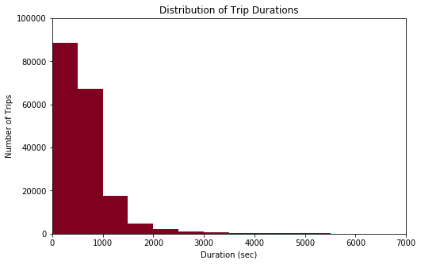

```python
Dist_duration_1(np.arange(0, data['duration_sec'].max()+500, 500), 'duration_sec', '#800020')
```

```python
def Dist_duration(bins, x, color):
    '''ploting distribution of duration'''
    plt.figure(figsize=[8,5])
    bins = np.arange(0, data['duration_sec'].max()+100, 100)
    plt.hist(data = data, x=x, bins = bins, color=color)
    # sb.displot(data=data, y='duration_sec', bins=bins, color='#800020')
    plt.axis([0, 3000, 0, 30000])
    plt.title(ChartTitle('Distribution of Trip Durations'))
    plt.xlabel('Duration (sec)')
    plt.ylabel('Number of Trips');
```

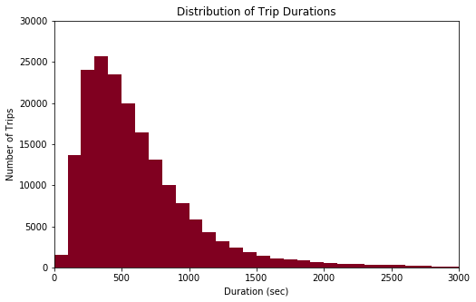

```python
Dist_duration(np.arange(0, data['duration_sec'].max()+100, 100), 'duration_sec', '#800020')
```

```python
def _station_plot(bins, data, x, color, xlabel, title):
    '''plot of Start station '''
    plt.figure(figsize=[18, 12])
    plt.hist(data = data, x = x, bins = bins, color=color)
    plt.xticks(range(10, 402, 10))
    plt.axis([0,420,0,30000])
    plt.title(ChartTitle(title))
    plt.xlabel(xlabel)
    plt.ylabel('Count');
```

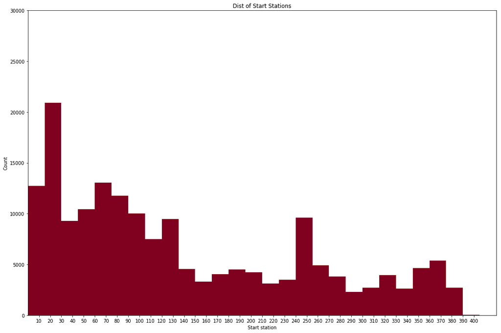

```python
# Plotting start station_id distribution
_station_plot(np.arange(0, data['start_station_id'].max()+15, 15),
                  data.dropna(), 'start_station_id', '#800020', 'Start station', 'Dist of Start Stations')
```

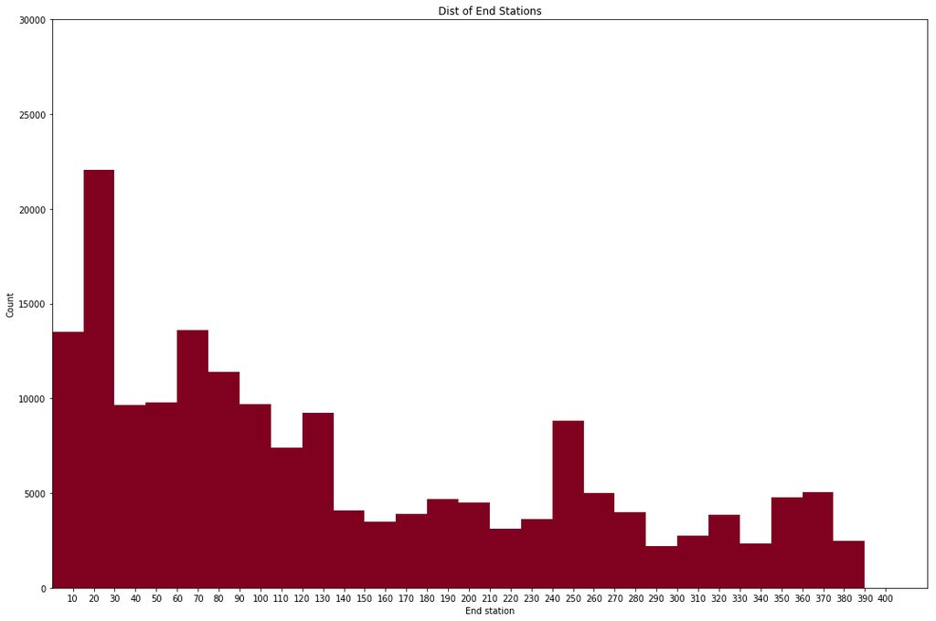

```python
# Plotting end station_id distribution
_station_plot(np.arange(0, data['end_station_id'].max()+15, 15),
                  data.dropna(), 'end_station_id', '#800020', 'End station', 'Dist of End Stations')
```

In the case of start and end station, as you can see, the start stations and end stations are same.

I'll now move on to the other variables in the dataset: age, user type, and gender.

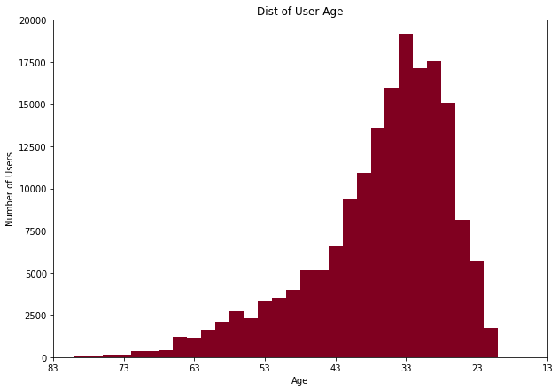

```python
# Plotting age distribution derived from member's birth year.
bins = np.arange(0, data['member_birth_year'].astype(float).max()+2, 2)

plt.figure(figsize=[10,7])
plt.hist(data = data.dropna(), x = 'member_birth_year', bins = bins, color='#800020')
# sb.kdeplot(data = data.dropna(), x = 'member_birth_year')
plt.axis([1939, 2009, 0, 20000])
plt.xticks([1939, 1949, 1959, 1969, 1979, 1989, 1999, 2009], [(2022-1939), (2022-1949), (2022-1959), (2022-1969), (2022-1979), (2022-1989), (2022-1999), (2022-2009)])
plt.title(ChartTitle('Dist of User Age'))
plt.xlabel('Age')
plt.ylabel('Number of Users');
```

In the case of age, you can see that the distribution is more concentrated between 20 to 50 years old.

```python
Usertype_index = data.user_type.value_counts().keys()
```

```python
def plot_1(title, ylabel, xlabel, x, y):
    '''a function to plot barplots across the project'''
    plt.figure(figsize=[10,7])
    sb.barplot(data=data, x=x, y=y,
               color="#800020").set(title=title, ylabel=ylabel, xlabel=xlabel);
```

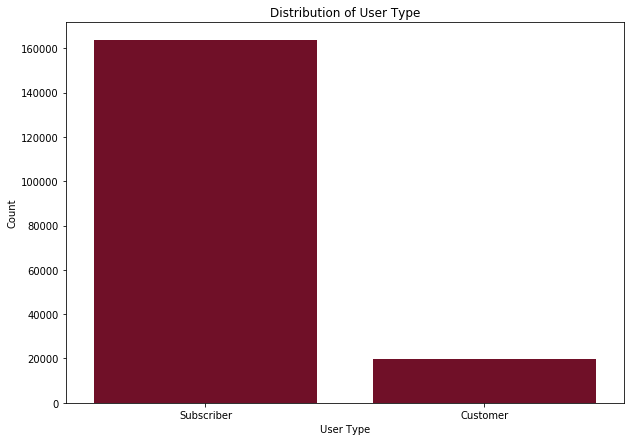

```python
# plotting Distribution of User Type
plot_1('Distribution of User Type', 'Count', 'User Type',
         Usertype_index, data.user_type.value_counts())
```

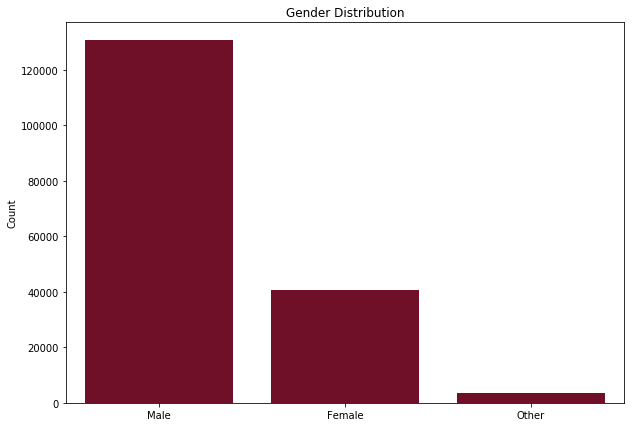

```python
# plot of Gender Distribution
plot_1('Gender Distribution', 'Count', '',
       data.member_gender.value_counts().keys(), data.member_gender.value_counts())
```

### Of the features you investigated, were there any unusual distributions? Did you perform any operations on the data to tidy, adjust, or change the form of the data? If so, why did you do this?

> When investigating the Birth year variables, Birth year is converted by substracting the year from current year in order to give the distibution for age and better perception. In addtion, start station and end station is plotted in a larger plot so that it gives a better insight regarding traffic of bikes at certain stations.

## Bivariate Exploration

> I want to look at the duration in seconds correlations present between features such as: age, start station, end station, user type, and gende in the data.

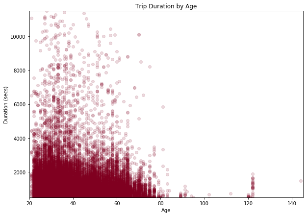

```python
plt.figure(figsize=[10,7])
# sb.scatterplot(data=data, x=2022 - data['member_birth_year'], y="duration_sec")
plt.scatter((2022 - data['member_birth_year']), data['duration_sec'], alpha = 0.15
            , color='#800020' )
plt.axis([20, 145, 500, 11500])
plt.title(ChartTitle('Trip Duration by Age'))
plt.xlabel('Age')
plt.ylabel('Duration (secs)');
```

By looking at the chart above, In the case of age, the distribution is more concentrated between 20 to 40 years old

```python
# !pip install seaborn --upgrade #or also !pip install seaborn==0.9.0
```

```python
sb.__version__
```

```
'0.8.1'
```

```python
sorted(data.start_station_id.unique())
```

[output not shown]

[output cut: 275 more lines]

[output not shown]

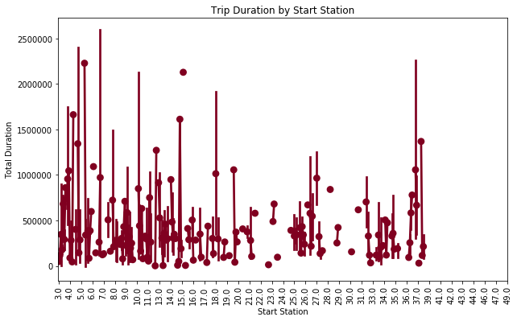

```python
S = []

start_station_ids = sorted(data.start_station_id.unique())
for x in start_station_ids :
    S.append(data[data.start_station_id == x].duration_sec.sum())
total_duration = pd.Series(S)

plt.figure(figsize = [10, 6])
sb.pointplot(x = data['start_station_id'], y = total_duration, color='#800020')
plt.xticks(range(0, 401, 10), rotation=90)
plt.title(ChartTitle('Trip Duration by Start Station'))
plt.xlabel('Start Station')
plt.ylabel('Total Duration');
```

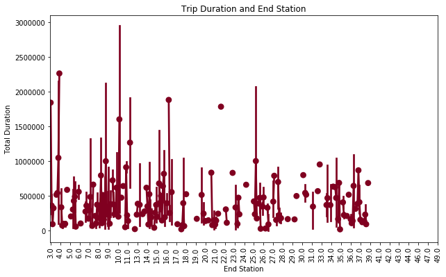

```python
E = []

end_station_ids = sorted(data.end_station_id.unique())
for x in end_station_ids :
    E.append(data[data.end_station_id == x].duration_sec.sum())
total_duration = pd.Series(E)

plt.figure(figsize = [10, 6])
sb.pointplot(x = data['end_station_id'], y = total_duration, color='#800020')
plt.xticks(range(0, 401, 10), rotation=90)
plt.title(ChartTitle('Trip Duration and End Station'))
plt.xlabel('End Station')
plt.ylabel('Total Duration');
```

You can observe that the trip duration is higher for some stations at the start station and higher for some stations at the final station. As a result, we can identify which stations initiate longer trips and which stations mark the conclusion of longer travels.

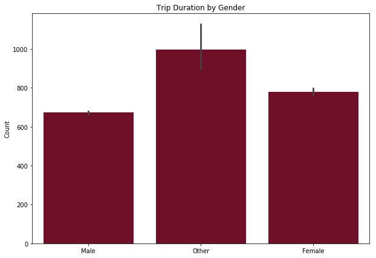

```python
#plotting Gender against trip duration
plot_1('Trip Duration by Gender', 'Count', '', 'member_gender', 'duration_sec')
```

Even though there are much more male riders than other and female riders, it is interesting to see that a higher percentage of women and other passengers take longer excursions.

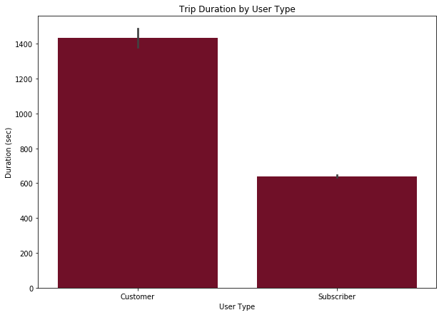

```python
#plotting trip duration against user types
plot_1('Trip Duration by User Type', 'Duration (sec)', 'User Type', 'user_type', 'duration_sec')
```

Interestingly, we can see that higher percentage of customer rides longer trips then subscriber although number of subscriber riders are very high then customer.

### Talk about some of the relationships you observed in this part of the investigation. How did the feature(s) of interest vary with other features in the dataset?

> Trip Duration is so dependendable on the age of the member, when the age between 20 to 45, the trip duration is higher than the older ages.

> However, Start station and end station does not much determine the trip duration. trip duration for some station for start station is higher and for some stations for end station is higher. As a result, we can see that what stations result in starting of longer trips and what stations comes end of longer trips.

### Did you observe any interesting relationships between the other features (not the main feature(s) of interest)?

> I thought that variables which are user type and gender values having higher value to get higher trip duration but it is the opposite. For gender, value of male members is very high but it got lower trip duration. For user type, value of subscriber members is very high but it got lower trip duration then customer.

## Multivariate Exploration

> The main thing I want to explore in this part of the analysis is how the three categorical measures of user type and gender into the relationship between trip duration and age.

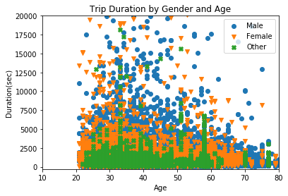

```python
gender_marker = [['Male', 'o'],
               ['Female', 'v'],
               ['Other', 'X']]

for gender, marker in gender_marker:
    data_gender = data[data['member_gender'] == gender]
    plt.scatter((2022 - data_gender['member_birth_year']), data_gender['duration_sec'], marker = marker, alpha= 1)
plt.legend(['Male','Female','Other'])
plt.axis([10, 80, -300, 20000 ])
plt.title(ChartTitle('Trip Duration by Gender and Age'))
plt.xlabel('Age')
plt.ylabel('Duration(sec)');
```

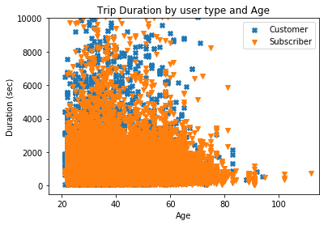

```python
User_type_marker = [['Customer', 'X'],['Subscriber', 'v']]

for user_type, marker in User_type_marker:
    data_type = data[data['user_type'] == user_type]
    plt.scatter((2022 - data_type['member_birth_year']), data_type['duration_sec'], marker = marker, alpha= 1)
plt.legend(['Customer','Subscriber'])
plt.axis([15, 115, -500, 10000 ])
plt.title(ChartTitle('Trip Duration by user type and Age'))
plt.xlabel('Age')
plt.ylabel('Duration (sec)');
```

For the age, duration, and gender, for the others leap at an older age (around 60 years) to got 3000 trip duration.

For the age, duration, and user type, both Customer and Subscriber are showing similar trends for age and trip duration, but for subscribers the trip duration is higher for older age.

```python
data['age'] = (2022 - data['member_birth_year'])
```

```python
 def plot_3(column, title):
    '''Trip Duration by Gender and Age  and user type'''
    gender = sb.FacetGrid(data = data, col = column, col_wrap = 2, size = 5,
                     xlim = [10,100], ylim = [-500, 9000])
    gender.map(plt.scatter, 'age', 'duration_sec', alpha= 0.1, color='#800020')

    gender.set(xlabel='Age', ylabel='Duration (sec)', title=ChartTitle(title));
```

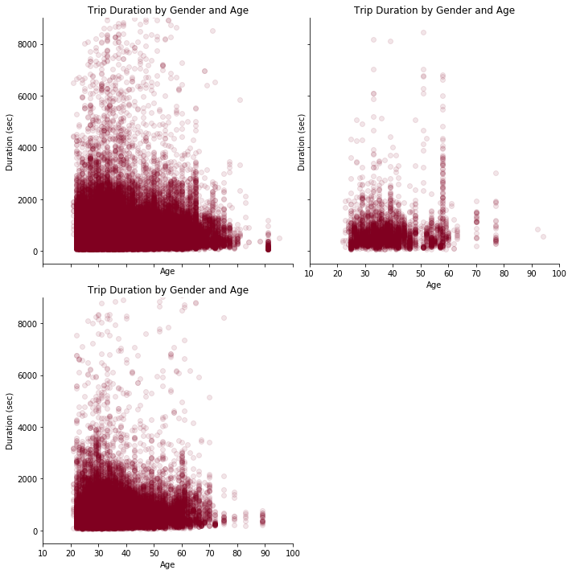

```python
#plot of Trip Duration by Gender and Age
plot_3('member_gender', 'Trip Duration by Gender and Age')
```

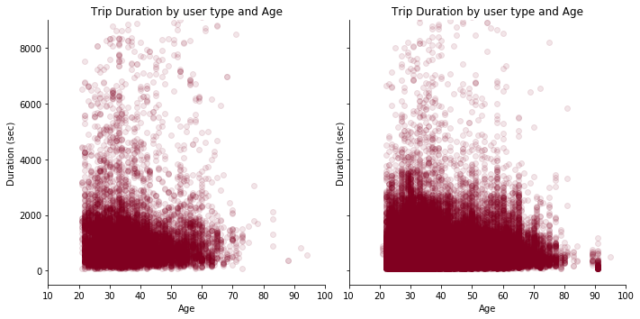

```python
#plot of Trip Duration by user type and Age
plot_3('user_type', 'Trip Duration by user type and Age')
```

For the age, duration, and gender, for the others leap at an older age (around 60 years) to got 3000 trip duration.

For the age, duration, and user type, both Customer and Subscriber are showing similar trends for age and trip duration, but for subscribers the trip duration is higher for older age.

### Talk about some of the relationships you observed in this part of the investigation. Were there features that strengthened each other in terms of looking at your feature(s) of interest?

I observed that although the number of users for male is higher but percentage is higher for women and other in trip duration. And,for the others leap at an older age (around 60 years) to got 3000 trip duration which is a peak. Also, for subscribers the trip duration is higher than customer for older age.

### Were there any interesting or surprising interactions between features?

Looking back on the plots, leaping for other gender at an older is a surprise. And, for subscribers the trip duration is higher than customer for older age is a surprise